# Advanced SQL Analytics using Superstore Dataset

## Objective

In this project, I used the Superstore dataset to practice advanced SQL concepts. I worked with Subqueries, Common Table Expressions (CTEs), and Window Functions to answer different business questions and understand customer sales performance.

## Step 1: Setup Data

First, I created a new database in MySQL and imported the Superstore dataset into a table named **superstore_raw**. After importing the data, I checked the table structure and verified that all records were loaded successfully.

# Database create

Code:

```
CREATE DATABASE advanced_sql_db;

USE advanced_sql_db;
```

-- Check imported data

SHOW TABLES;

**Output:**

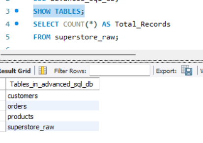

SELECT COUNT(*) AS Total_Records FROM superstore_raw;

**Output:**

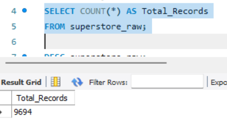

DESC superstore_raw;

**Output:**

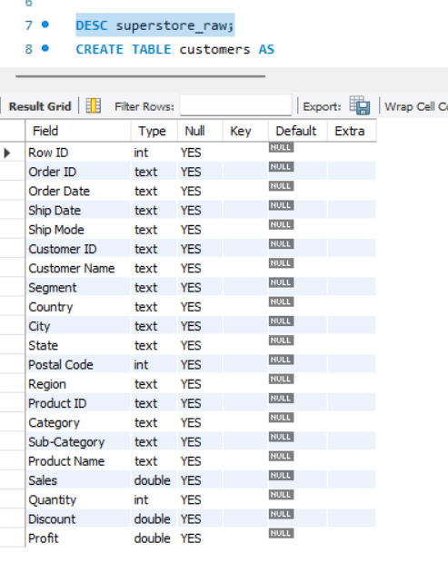

## Step 2: Create Customers, Orders and Products Tables

The raw dataset contains repeated customer, order, and product information. To make the data easier to work with, I created separate tables using **SELECT DISTINCT**.

-- Renamed the column names to make them short and easy to use

```
CREATE TABLE customers AS
SELECT DISTINCT
    `Customer ID` AS customer_id,
    `Customer Name` AS customer_name,
    Segment AS segment
FROM superstore_raw;

CREATE TABLE orders AS
SELECT DISTINCT
    `Order ID` AS order_id,
    `Order Date` AS order_date,
    `Ship Date` AS ship_date,
    `Ship Mode` AS ship_mode,
    `Customer ID` AS customer_id,
    Sales AS sales,
    Quantity AS quantity,
    Discount AS discount,
    Profit AS profit
FROM superstore_raw;

CREATE TABLE products AS
SELECT DISTINCT
    `Product ID` AS product_id,
    `Product Name` AS product_name,
    Category AS category,
    `Sub-Category` AS sub_category
FROM superstore_raw;
```

## Step 3: Subqueries

In this step, I used subqueries to compare sales values with average sales and to find the highest sales order for each customer.

```
-- Q1. Find all orders where sales are greater than the average sales. (Subquery)
```

```
SELECT *
FROM orders
WHERE sales >
(
SELECT AVG(sales)
FROM orders
);
```

**Output:**

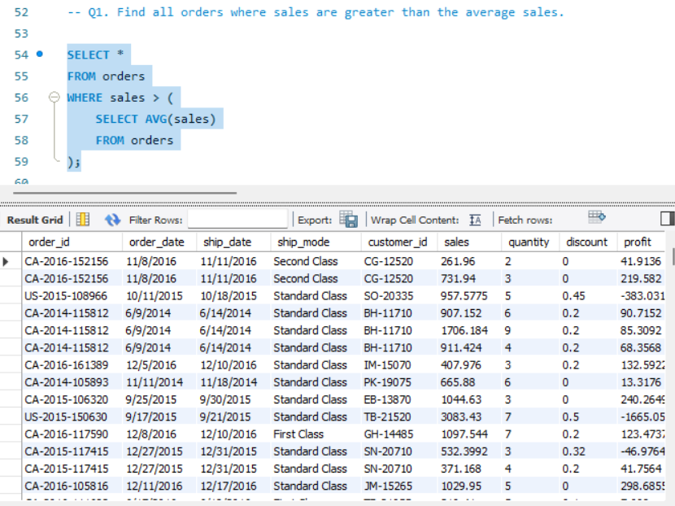

```
-- Q2. Find the highest sales order for each customer. (Subquery)
```

```
SELECT *
FROM orders o
WHERE sales = (
    SELECT MAX(sales)
    FROM orders
    WHERE customer_id = o.customer_id
);
```

**Output:**

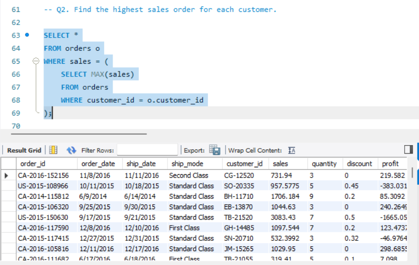

## Step 4: Common Table Expressions (CTEs)

CTEs helped me calculate customer sales in a simple and readable way. They also made it easy to compare customer sales with the average sales.

```
-- Q3. Calculate total sales for each customer. (CTE)
```

```
WITH customer_sales AS (
    SELECT
        customer_id,
        SUM(sales) AS total_sales
    FROM orders
    GROUP BY customer_id
)

SELECT *
FROM customer_sales;
```

**Output:**

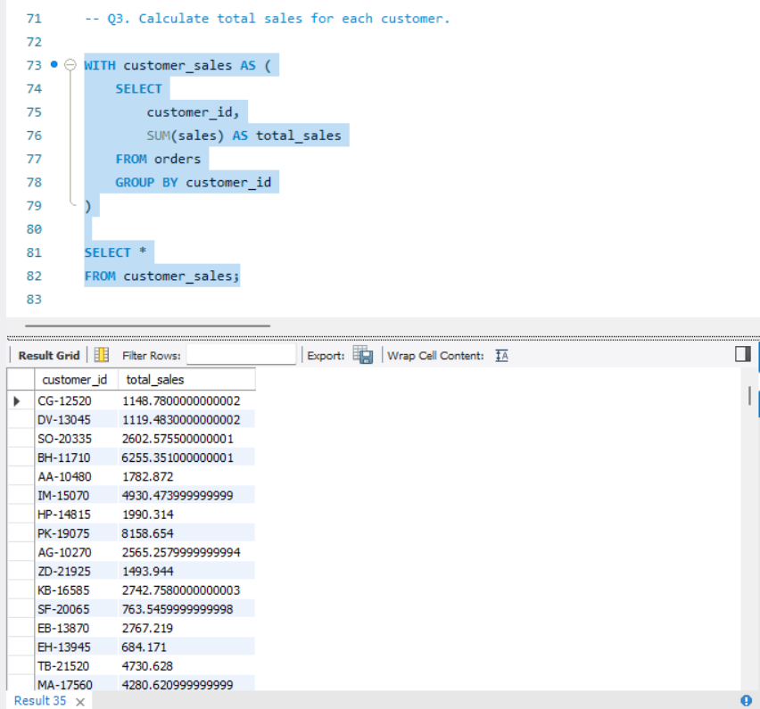

```
-- Q4. Find customers whose total sales are above average. (CTE + Subquery)
```

```
WITH customer_sales AS (
    SELECT
        customer_id,
        SUM(sales) AS total_sales
    FROM orders
    GROUP BY customer_id
)

SELECT *
FROM customer_sales
WHERE total_sales > (
    SELECT AVG(total_sales)
    FROM customer_sales
);
```

**Output:**

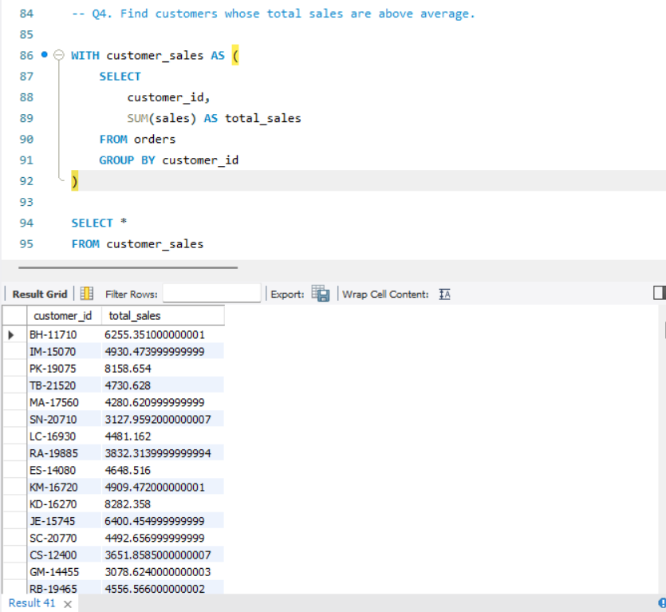

## Step 5: Window Functions

Window functions helped me rank customers based on sales and assign row numbers to orders without changing the original data.

```
-- Q5. Rank all customers based on total sales. (Window Function)
```

```
SELECT
    customer_id,
    SUM(sales) AS total_sales,
    RANK() OVER (ORDER BY SUM(sales) DESC) AS customer_rank
FROM orders
GROUP BY customer_id;
```

**Output:**

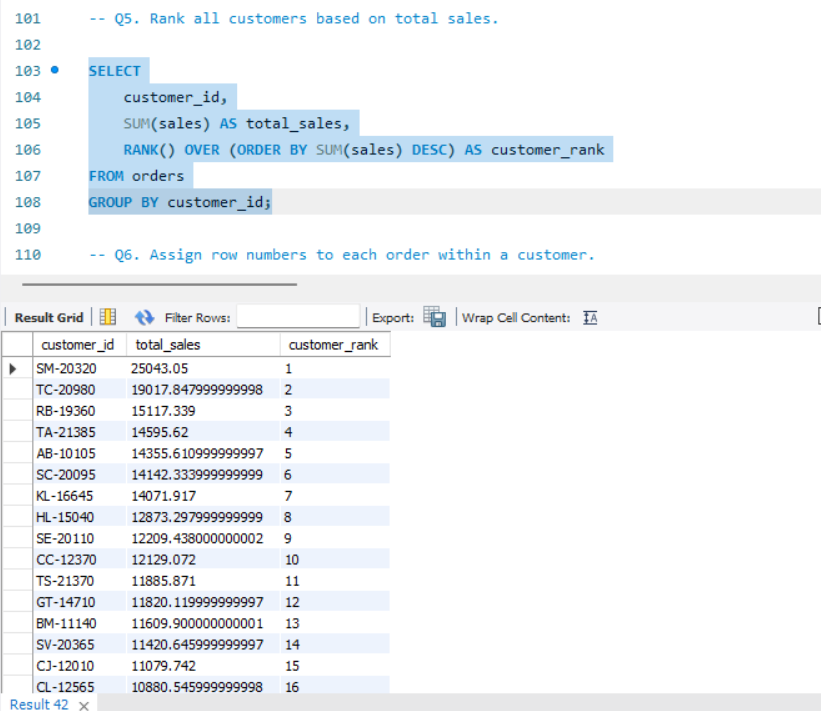

```
-- Q6. Assign row numbers to each order within a customer. (Window Function + PARTITION BY)
```

```
SELECT
    customer_id,
    order_id,
    sales,
    ROW_NUMBER() OVER (
        PARTITION BY customer_id
        ORDER BY order_id
    ) AS order_number
FROM orders;
```

**Output:**

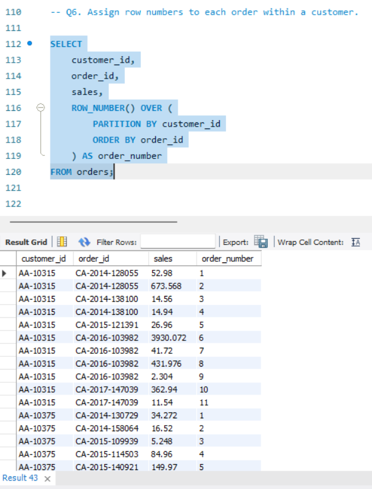

```
-- Q7. Display top 3 customers based on total sales. (Window Function)
```

```
WITH customer_sales AS
(
    SELECT
        customer_id,
        SUM(sales) AS total_sales
    FROM orders
    GROUP BY customer_id
)

SELECT
    customer_id,
    total_sales
FROM
(
    SELECT
        customer_id,
        total_sales,
        DENSE_RANK() OVER (ORDER BY total_sales DESC) AS customer_rank
    FROM customer_sales
) ranked_customers
WHERE customer_rank <= 3;
```

**Output:**

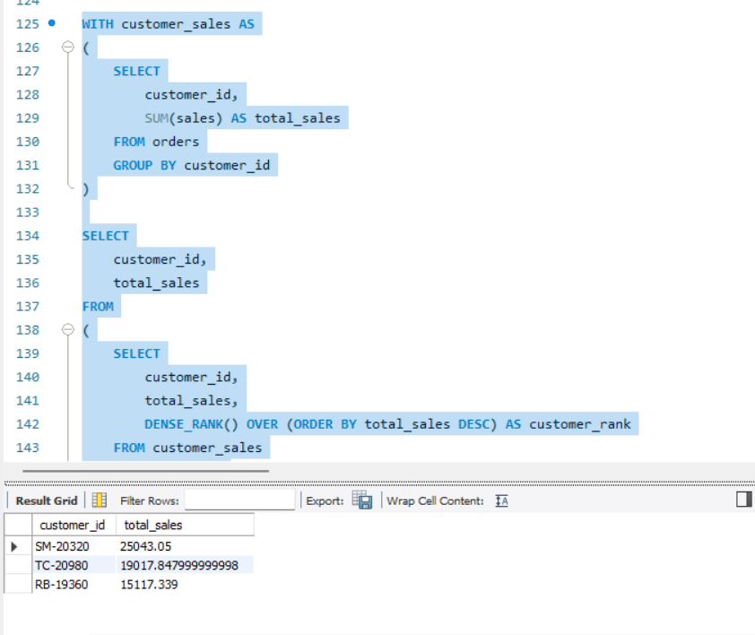

## Step 6: Final Combined Query

In this query, I combined a JOIN, a CTE, and a Window Function to display customer name, total sales, and sales rank in a single result.

```
-- Who are the top 5 customers?
```

```
SELECT
customer_id,
SUM(sales) AS total_sales
FROM orders
GROUP BY customer_id
ORDER BY total_sales DESC
LIMIT 5;
```

**Output:**

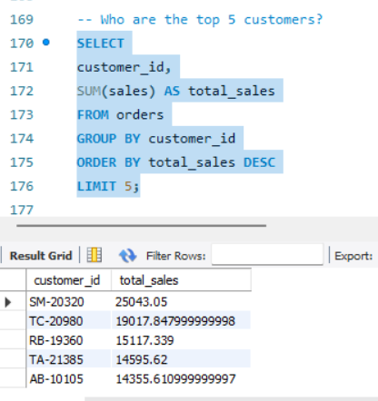

```
-- Who are the bottom 5 customers?
```

```
SELECT
customer_id,
SUM(sales) AS total_sales
FROM orders
GROUP BY customer_id
ORDER BY total_sales
LIMIT 5;
```

**Output:**

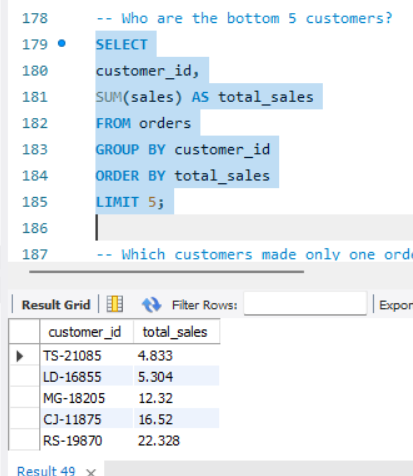

```
-- Which customers made only one order?
```

```
SELECT
customer_id,
COUNT(order_id) AS total_orders
FROM orders
GROUP BY customer_id
HAVING COUNT(order_id) = 1;
```

**Output:**

[figure not shown]

```
-- Which customers have above-average sales?
```

```
WITH customer_sales AS
(
SELECT
customer_id,
SUM(sales) AS total_sales
FROM orders
GROUP BY customer_id
)

SELECT *
FROM customer_sales
WHERE total_sales>
(
SELECT AVG(total_sales)
FROM customer_sales
);
```

**Output:**

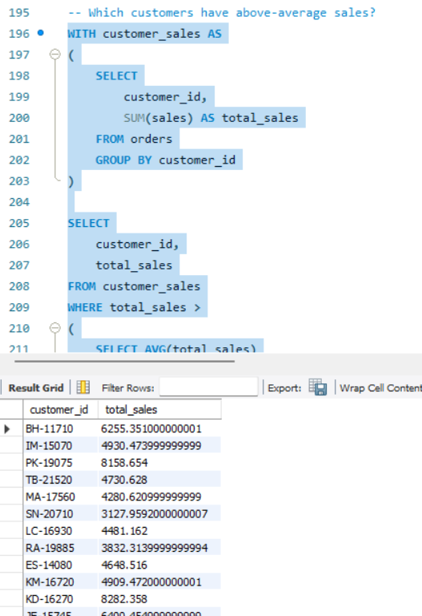

```
-- What is the highest order value per customer?
```

```
SELECT
customer_id,
MAX(sales) AS highest_order_value
FROM orders
GROUP BY customer_id;
```

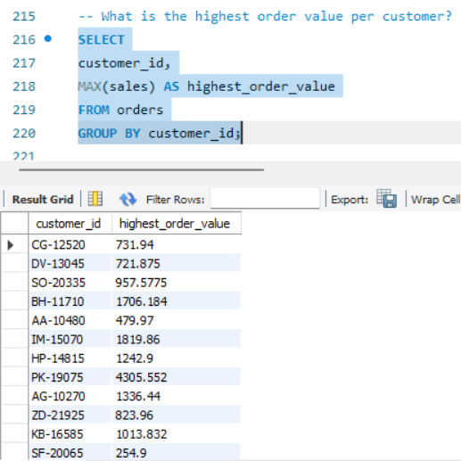

**Combined Code:**

```
-- Final Query
-- Show customer name, total sales and rank

WITH customer_sales AS
(
    SELECT
        customer_id,
        SUM(sales) AS total_sales
    FROM orders
    GROUP BY customer_id
)

SELECT
    customer_name,
    total_sales,
    RANK() OVER(ORDER BY total_sales DESC) AS customer_rank
FROM customer_sales
JOIN customers
ON customer_sales.customer_id = customers.customer_id;
```

**Output:**

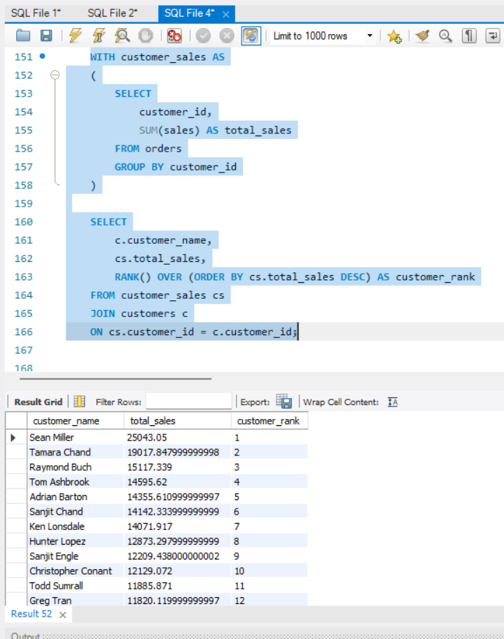

## Key Insights

- The Superstore dataset contains **9694 records**, which were loaded successfully into the database.
- I created separate **customers**, **orders**, and **products** tables from the raw dataset using `SELECT DISTINCT`.
- I used a **Subquery** to find all orders where the sales value is higher than the average sales.
- Another subquery helped me identify the **highest sales order for each customer**.
- Using a **CTE**, I calculated the total sales of every customer, which made the queries easier to read.
- I found that only some customers have **total sales greater than the average customer sales**.
- With the help of **RANK()**, I ranked customers based on their total sales.
- I used **ROW_NUMBER()** with `PARTITION BY` to give each order a separate number for every customer.
- Finally, I combined **JOIN**, **CTE**, and **Window Functions** to display the customer name, total sales, and customer rank in a single query.